# Feature Engineering and Modelling

1. Import packages
2. Load data
3. Modelling

## 1. Import packages

```python
import warnings
warnings.filterwarnings("ignore", category=FutureWarning)
```

```python
import pandas as pd
import numpy as np
import seaborn as sns
from datetime import datetime
import matplotlib.pyplot as plt

# Shows plots in jupyter notebook
%matplotlib inline

# Set plot style
sns.set(color_codes=True)
```

## 2. Load data

```python
df = pd.read_csv('./data_for_predictions.csv')
df.drop(columns=["Unnamed: 0"], inplace=True)
df.head()
```

|  | id | cons_12m | cons_gas_12m | cons_last_month | forecast_cons_12m | forecast_discount_energy | forecast_meter_rent_12m | forecast_price_energy_off_peak | forecast_price_energy_peak | forecast_price_pow_off_peak | ... | months_modif_prod | months_renewal | channel_MISSING | channel_ewpakwlliwisiwduibdlfmalxowmwpci | channel_foosdfpfkusacimwkcsosbicdxkicaua | channel_lmkebamcaaclubfxadlmueccxoimlema | channel_usilxuppasemubllopkaafesmlibmsdf | origin_up_kamkkxfxxuwbdslkwifmmcsiusiuosws | origin_up_ldkssxwpmemidmecebumciepifcamkci | origin_up_lxidpiddsbxsbosboudacockeimpuepw |
| --- | --- | --- | --- | --- | --- | --- | --- | --- | --- | --- | --- | --- | --- | --- | --- | --- | --- | --- | --- | --- | --- |
| 0 | 24011ae4ebbe3035111d65fa7c15bc57 | 0.000000 | 4.739944 | 0.000000 | 0.000000 | 0.0 | 0.444045 | 0.114481 | 0.098142 | 40.606701 | ... | 2 | 6 | 0 | 0 | 1 | 0 | 0 | 0 | 0 | 1 |
| 1 | d29c2c54acc38ff3c0614d0a653813dd | 3.668479 | 0.000000 | 0.000000 | 2.280920 | 0.0 | 1.237292 | 0.145711 | 0.000000 | 44.311378 | ... | 76 | 4 | 1 | 0 | 0 | 0 | 0 | 1 | 0 | 0 |
| 2 | 764c75f661154dac3a6c254cd082ea7d | 2.736397 | 0.000000 | 0.000000 | 1.689841 | 0.0 | 1.599009 | 0.165794 | 0.087899 | 44.311378 | ... | 68 | 8 | 0 | 0 | 1 | 0 | 0 | 1 | 0 | 0 |
| 3 | bba03439a292a1e166f80264c16191cb | 3.200029 | 0.000000 | 0.000000 | 2.382089 | 0.0 | 1.318689 | 0.146694 | 0.000000 | 44.311378 | ... | 69 | 9 | 0 | 0 | 0 | 1 | 0 | 1 | 0 | 0 |
| 4 | 149d57cf92fc41cf94415803a877cb4b | 3.646011 | 0.000000 | 2.721811 | 2.650065 | 0.0 | 2.122969 | 0.116900 | 0.100015 | 40.606701 | ... | 71 | 9 | 1 | 0 | 0 | 0 | 0 | 1 | 0 | 0 |

5 rows × 63 columns

## 3. Modelling

We now have a dataset containing features that we have engineered and we are ready to start training a predictive model. Remember, we only need to focus on training a `Random Forest` classifier.

```python
from sklearn import metrics
from sklearn.model_selection import train_test_split
from sklearn.ensemble import RandomForestClassifier
```

### Data sampling

The first thing we want to do is split our dataset into training and test samples. The reason why we do this, is so that we can simulate a real life situation by generating predictions for our test sample, without showing the predictive model these data points. This gives us the ability to see how well our model is able to generalise to new data, which is critical.

A typical % to dedicate to testing is between 20-30, for this example we will use a 75-25% split between train and test respectively.

```python
# Make a copy of our data
train_df = df.copy()

# Separate target variable from independent variables
y = df['churn']
X = df.drop(columns=['id', 'churn'])
print(X.shape)
print(y.shape)
```

```
(14606, 61)
(14606,)
```

```python
X_train, X_test, y_train, y_test = train_test_split(X, y, test_size=0.25, random_state=42)
print(X_train.shape)
print(y_train.shape)
print(X_test.shape)
print(y_test.shape)
```

```
(10954, 61)
(10954,)
(3652, 61)
(3652,)
```

### Model training

Once again, we are using a `Random Forest` classifier in this example. A Random Forest sits within the category of `ensemble` algorithms because internally the `Forest` refers to a collection of `Decision Trees` which are tree-based learning algorithms. As the data scientist, you can control how large the forest is (that is, how many decision trees you want to include).

The reason why an `ensemble` algorithm is powerful is because of the laws of averaging, weak learners and the central limit theorem. If we take a single decision tree and give it a sample of data and some parameters, it will learn patterns from the data. It may be overfit or it may be underfit, but that is now our only hope, that single algorithm.

With `ensemble` methods, instead of banking on 1 single trained model, we can train 1000's of decision trees, all using different splits of the data and learning different patterns. It would be like asking 1000 people to all learn how to code. You would end up with 1000 people with different answers, methods and styles! The weak learner notion applies here too, it has been found that if you train your learners not to overfit, but to learn weak patterns within the data and you have a lot of these weak learners, together they come together to form a highly predictive pool of knowledge! This is a real life application of many brains are better than 1.

Now instead of relying on 1 single decision tree for prediction, the random forest puts it to the overall views of the entire collection of decision trees. Some ensemble algorithms using a voting approach to decide which prediction is best, others using averaging.

As we increase the number of learners, the idea is that the random forest's performance should converge to its best possible solution.

Some additional advantages of the random forest classifier include:

- The random forest uses a rule-based approach instead of a distance calculation and so features do not need to be scaled
- It is able to handle non-linear parameters better than linear based models

On the flip side, some disadvantages of the random forest classifier include:

- The computational power needed to train a random forest on a large dataset is high, since we need to build a whole ensemble of estimators.
- Training time can be longer due to the increased complexity and size of thee ensemble

```python
# Create and train the Random Forest classifier

model = RandomForestClassifier(
    n_estimators=100,
    random_state=42,
    n_jobs=-1
)

model.fit(X_train, y_train)

print("Random Forest model trained successfully.")
```

```
Random Forest model trained successfully.
```

### Evaluation

Now let's evaluate how well this trained model is able to predict the values of the test dataset.

```python
# Generate predictions for the test dataset

y_pred = model.predict(X_test)

print("Predictions generated successfully.")
print("Number of predictions:", len(y_pred))
```

```
Predictions generated successfully.
Number of predictions: 3652
```

```python
# Calculate classification performance metrics

accuracy = metrics.accuracy_score(y_test, y_pred)
precision = metrics.precision_score(y_test, y_pred)
recall = metrics.recall_score(y_test, y_pred)
f1 = metrics.f1_score(y_test, y_pred)

print("Accuracy :", round(accuracy, 4))
print("Precision:", round(precision, 4))
print("Recall   :", round(recall, 4))
print("F1 Score :", round(f1, 4))
```

```
Accuracy : 0.9031
Precision: 0.7143
Recall   : 0.0546
F1 Score : 0.1015
```

```python
# Confusion matrix

confusion_matrix = metrics.confusion_matrix(y_test, y_pred)

print("Confusion Matrix:")
print(confusion_matrix)
```

```
Confusion Matrix:
[[3278    8]
 [ 346   20]]
```

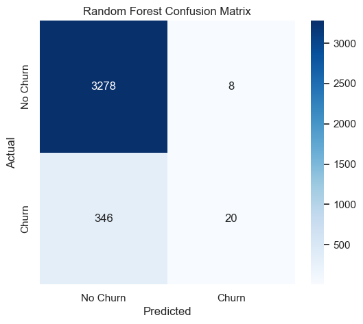

```python
# Visualize the confusion matrix

plt.figure(figsize=(6, 5))

sns.heatmap(
    confusion_matrix,
    annot=True,
    fmt='d',
    cmap='Blues',
    xticklabels=['No Churn', 'Churn'],
    yticklabels=['No Churn', 'Churn']
)

plt.xlabel('Predicted')
plt.ylabel('Actual')
plt.title('Random Forest Confusion Matrix')
plt.show()
```

```python
# Calculate ROC-AUC using predicted churn probabilities

y_prob = model.predict_proba(X_test)[:, 1]

roc_auc = metrics.roc_auc_score(y_test, y_prob)

print("ROC-AUC:", round(roc_auc, 4))
```

```
ROC-AUC: 0.6649
```

```python
# Detailed classification report

print("Classification Report:")
print(metrics.classification_report(y_test, y_pred))
```

```
Classification Report:
              precision    recall  f1-score   support

           0       0.90      1.00      0.95      3286
           1       0.71      0.05      0.10       366

    accuracy                           0.90      3652
   macro avg       0.81      0.53      0.53      3652
weighted avg       0.89      0.90      0.86      3652
```

### Evaluation Metrics

Several evaluation metrics were used to assess the Random Forest classifier.

**Accuracy** measures the overall proportion of correctly classified customers. However, accuracy alone is not sufficient for this problem because the churn class is much smaller than the non-churn class.

**Precision** measures the proportion of customers predicted as churners who actually churned. This is useful because it indicates how reliable the model's churn predictions are.

**Recall** measures the proportion of actual churners that the model successfully identifies. Recall is particularly important for this business problem because failing to identify a customer who is likely to churn may result in a missed opportunity for PowerCo to take preventive action.

**F1-score** combines precision and recall into a single metric and is useful when there is an imbalance between the classes.

**ROC-AUC** measures the model's ability to distinguish between churners and non-churners across different classification thresholds.

Therefore, accuracy was considered alongside precision, recall, F1-score and ROC-AUC rather than being used as the only measure of model performance.

### Model Performance Assessment

The Random Forest model achieved an accuracy of **90.31%**, which initially appears strong. However, accuracy is not sufficient to judge the performance of this model because the dataset contains substantially more non-churners than churners.

The model achieved a precision of **71.43%**, meaning that when it predicted a customer would churn, the prediction was correct in most cases. However, the recall was only **5.46%**, meaning that the model identified only a small proportion of the customers who actually churned.

The confusion matrix shows that the model correctly identified **20 churners**, but failed to identify **346 actual churners**. The F1-score of **10.15%** also indicates a poor balance between precision and recall. The ROC-AUC score of **0.6649** suggests that the model has some ability to distinguish between churners and non-churners, but its discriminatory performance is only moderate.

Therefore, the model performance is **not satisfactory for the business objective of identifying customers at risk of churn**. Although the overall accuracy is high, the very low recall means that the model would miss most customers who actually churn. Further model improvement, such as addressing class imbalance and tuning the model or classification threshold, would be required before using it for a real-world churn prevention strategy.

```python
# Identify the most important features in the Random Forest model

feature_importance = pd.DataFrame({
    'Feature': X_train.columns,
    'Importance': model.feature_importances_
})

feature_importance = feature_importance.sort_values(
    by='Importance',
    ascending=False
)

feature_importance.head(10)
```

|  | Feature | Importance |
| --- | --- | --- |
| 0 | cons_12m | 0.051672 |
| 14 | net_margin | 0.049589 |
| 5 | forecast_meter_rent_12m | 0.049370 |
| 11 | margin_gross_pow_ele | 0.047671 |
| 12 | margin_net_pow_ele | 0.046966 |
| 3 | forecast_cons_12m | 0.046268 |
| 15 | pow_max | 0.035858 |
| 2 | cons_last_month | 0.034973 |
| 49 | months_activ | 0.032355 |
| 10 | imp_cons | 0.031554 |

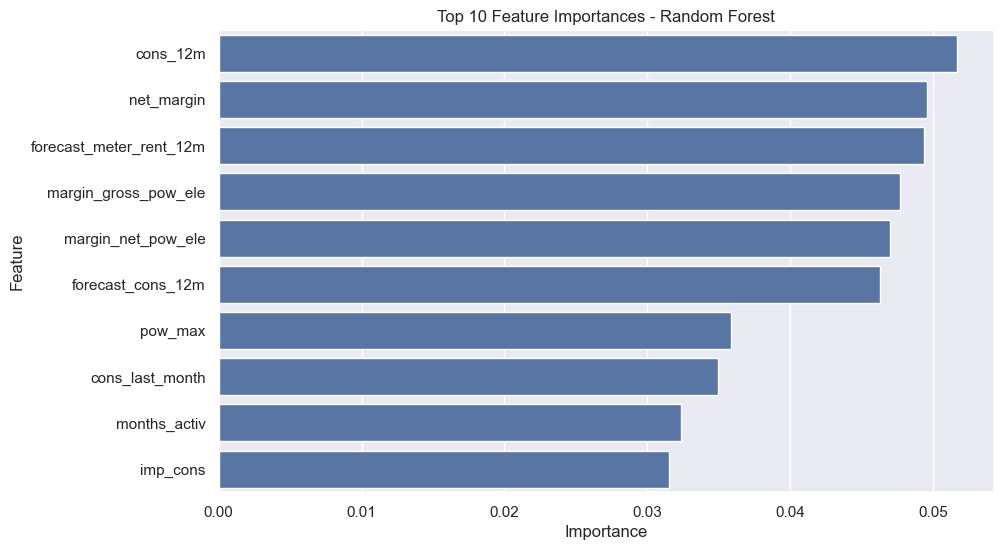

```python
# Visualize the top 10 most important features

top_features = feature_importance.head(10)

plt.figure(figsize=(10, 6))
sns.barplot(
    data=top_features,
    x='Importance',
    y='Feature'
)

plt.title('Top 10 Feature Importances - Random Forest')
plt.xlabel('Importance')
plt.ylabel('Feature')
plt.show()
```

### Feature Importance Analysis

The Random Forest feature importance analysis shows that `cons_12m` is the most important feature among the variables used by the model. Other highly influential features include `net_margin`, `forecast_meter_rent_12m`, `margin_gross_pow_ele`, `margin_net_pow_ele`, and `forecast_cons_12m`.

These features relate mainly to customer consumption, financial margins, forecasted consumption and meter-related charges. This suggests that customer usage and financial characteristics provide useful information for distinguishing between churn and non-churn customers.

Feature importance indicates which variables contributed most to the Random Forest's predictions, but it does not by itself establish a causal relationship between a feature and customer churn.

### Overall Conclusion

The Random Forest classifier achieved an accuracy of 90.31%, precision of 71.43%, recall of 5.46%, F1-score of 10.15%, and ROC-AUC of 0.6649.

Although the accuracy appears high, the confusion matrix shows that the model correctly identified only 20 of the 366 actual churners, while 346 churners were incorrectly classified as non-churners. Therefore, the model's ability to identify customers who are actually at risk of churn is limited.

The low recall is particularly important because identifying potential churners is the main business objective. The model would therefore require further improvement before being considered suitable for deployment, potentially through addressing class imbalance, tuning the Random Forest, or adjusting the classification threshold.

The feature importance analysis provides additional insight into the variables that contributed most to the model's predictions, with customer consumption, margins and forecast-related variables among the most important features.